# Select your own disparity metric

Thomas Guillerme

2025-01-03

Here is a vignette to help you select a list of disparity metrics tailored to your own dataset and your own biological question. We will be doing that using the `dispRity` package Guillerme (2018). You can find the slides introducing this vignette [here](https://tguillerme.github.io/Top_10_disparity_metrics.pdf). And a recording of the whole workshop [here](https://www.youtube.com/watch?v=JKpUQbxID9A).

```r
## Installing the package
install.packages("dispRity")
## Loading the package
library(dispRity)
```

> You feel uncomfortable with `R`? You can also follow this tutorial using the [`moms` graphical interface](https://tguillerme.shinyapps.io/moms/).

# 2 - Select a dataset

> Note that for the purpose of the exercise step 1 and 2 are reverted here. I would argue that having a biological question should be the first step but in practice, it’s also often totally fine to start with the dataset and then figure out which question would be cool to study.

For the purpose of this dataset, we will use one of the demo dataset from the `dispRity` package, but feel free to choose one of the other demo dataset or, even better, use your own dataset!

```r
## Loading the demo datasets
data(demo_data)
```

Here is a summary of the demo datasets you can choose from:

| study | field | taxonomic group | traits | trait space | size | groups | question |
| --- | --- | --- | --- | --- | --- | --- | --- |
| Beck and Lee (2014) | Palaeontology | Mammalia | discrete morphological phylogenetic data | Ordination of a distance matrix (PCO) | 106x105 | 52 crown vs. 54 stem | Are living mammals and their ancestors more disparate than their stem mammals? |
| Wright (2017) | Palaeontology | Crinoidea | discrete morphological phylogenetic data | Ordination of a distance matrix (PCO) | 42x41 | 16 before vs. 23 after | Is there an effect of the mass Ordovician mass extinction on crinoids disparity? |
| Marcy et al. (2016) | Evolution | Rodentia | skull 2D landmark coordinates | Ordination of a Procrustes Superimposition (PCA) | 454x134 | 225 *Megascapheus* vs. 229 *Thomomys* | Is there convergence in skull shape between these two genera of gophers? |
| Hopkins and Pearson (2016) | Evolution | Trilobita | 3D landmark coordinates | Ordination of a Procrustes Superimposition (PCA) | 46x46 | 36 adults vs. 10 juveniles | How are trilobites growing? |
| Jones et al. (2015) | Ecology | Plantae | Communities species compositions | Ordination of a Jaccard distance matrix (PCO) | 48x47 | 24 aspens vs. 24 grasslands | Are aspens and grasslands dispersing differently? |
| Healy et al. (2019) | Ecology | Animalia | Life history traits | Ordination of continuous traits (PCA) | 285*6 | 83 ecthotherms vs. 202 endotherms | Do endotherms have more diversified life history strategies than ectotherms? |

For this example I will be using the dataset from Beck and Lee (2014).

```r
## Selecting a dataset
my_data <- demo_data$beck
```

> If you want to use your own data, you’ll have to make it into a `dispRity` object to follow this tutorial easily. This can be easily done using `custom.subsets` or `chrono.subsets` depending if you want to group your data by a certain variable or through time. You can refer to the use of each function (and all other ones) using `?custom.subsets` or `?chrono.subsets`.

> In `moms` select in the “Select the type of space to use:” menu (top left), choose “Demo” and select your favourite dataset in the “Select a demo matrix” list. You can also input your own matrix using choosing “Input” in the “Select the type of space to use:” menu (top left) and then choose a file.

## Have a look at your dataset

The rest of the choice of metrics will depend on the properties of your dataset. Although there is advanced ways to correctly measure properties of multidimensional dasets (homscedasticity, normality, etc.), visualising can already tell a lot.

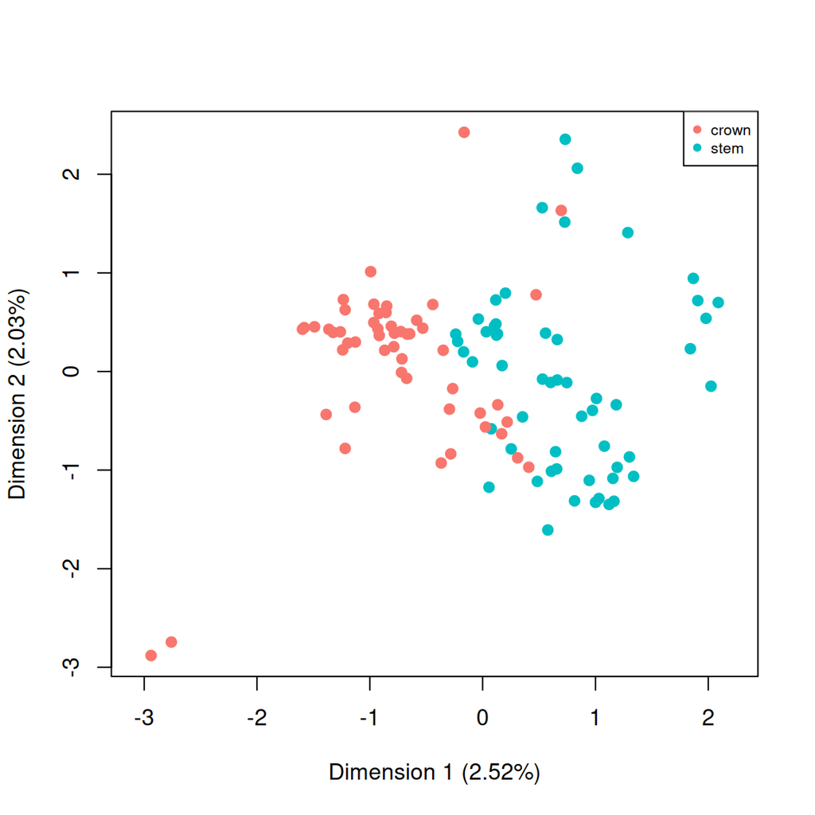

```r
## Visualising the two first dimensions
plot(my_data)
```

Note however that the dataset has 103 other dimensions so a 2 visualisation is often only superficial.

# 1 - Identify the mechanism and the process

With the dataset in mind, we can then identify the mechanism and the process at hand (or the other way around). In the chosen example, we can ask the question *“Do modern mammals (crown) evolve more disparate body shapes than archaic ones?”*. The mechanism here would be simply be **evolution** and the process here will be the age of the group. In other words, is there does “evolution has an effect (e.g. a different outcome) on the age of the group?”.

We can then choose a pattern: the disparity metric, function diversity metric, dissimilarity metric, space occupancy metric, etc.

# 3 - Select an aspect of the trait space that will answer your question

In terms of disparity here, we might be interested in two aspects: the diversity of body shapes can be expressed as changes in:

- size: for example the more trait space occupied, the more diverse a group is.
- density: for example more densily packed a part of the trait space is, the more diverse a group is.

In a very contrasting scenario, we’d have a group that has a big size and high density against one with a small size and low density.

# 4 - Make a list of potential metrics

There is no miracle recipe for making a list of metrics. One easy way is to first look at what has been done before (e.g. what are they using in your favourite paper). For example, we have tested and played around with a diversity of metrics in Guillerme et al. (2020) and Guillerme et al. (2024) (TL:DR; for both papers: different things measure things differently).

## Changes in size of the trait space:

1. sum of ranges? *The sum of the spreads of the data (spreads perimeter?).*
2. product of ranges? *The surface/volume/hypervolume of the square/cube/hypercube that contains all the data.*
3. sum of variances? *Same as for the sum of ranges but using the squared standard deviation in the data rather than the spread.*
4. product of variances? *Same as for the product of ranges but using the squared standard deviation in the data rather than the spread.*
5. convex hull surface? *The surface of the smallest polygon that contains all the data.*
6. convex hull volume? *The volume of the smallest polygon that contains all the data.*

Note here that the sum and products pairs for the ranges and variances are effectively measuring either the “perimeter” or the “surface/volume” in *n* dimensions.

## Changes in density of the trait space:

7. mean distance to centroid? *The average distance between the group center and each observation.*
8. mean nearest neighbor distance? *The average distance between each observation and it’s closest relative.*
9. mean squared pairwise distance (like in `dtt`)? *The average pairwise distance - but squared?*
10. minimum spanning tree average length? *The average branch length of the shortest tree that connects all observations.*

Alternatively, you can design your very own metric! We’ll see a how to example later on.

# 5 - Test which metric would best work for your dataset and question

Once we have our list, we can test it using the `dispRity` package.

To test the metric, it’s relatively easy, you can just use the `test.metric` function. This function will gradually transform your trait space space following one of the implemented algorithm and show how your metric changes in response to the changes in trait space.

The different transformations (called “shifts”) that are currently implemented are:

- `"random"`: just randomly removing data:

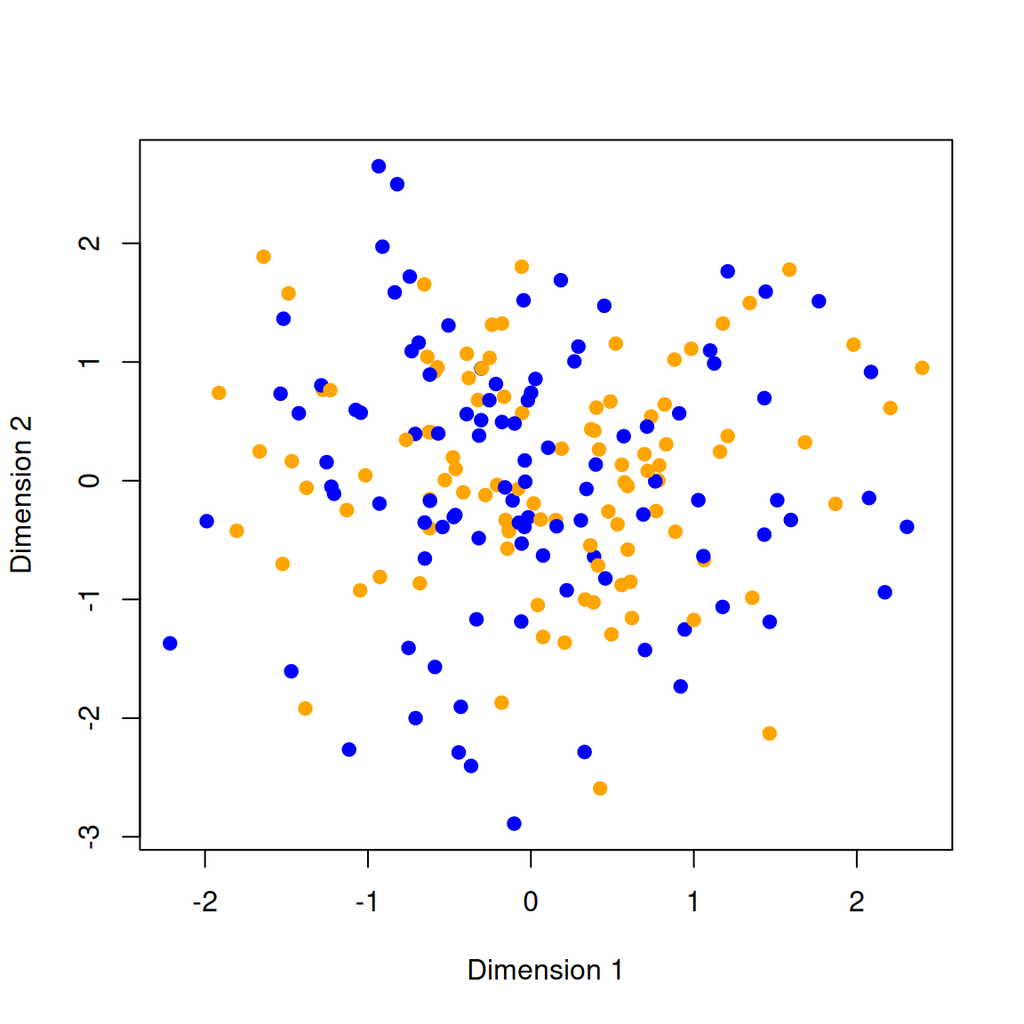

- `"size"`: removing data from the edges of the trait space:

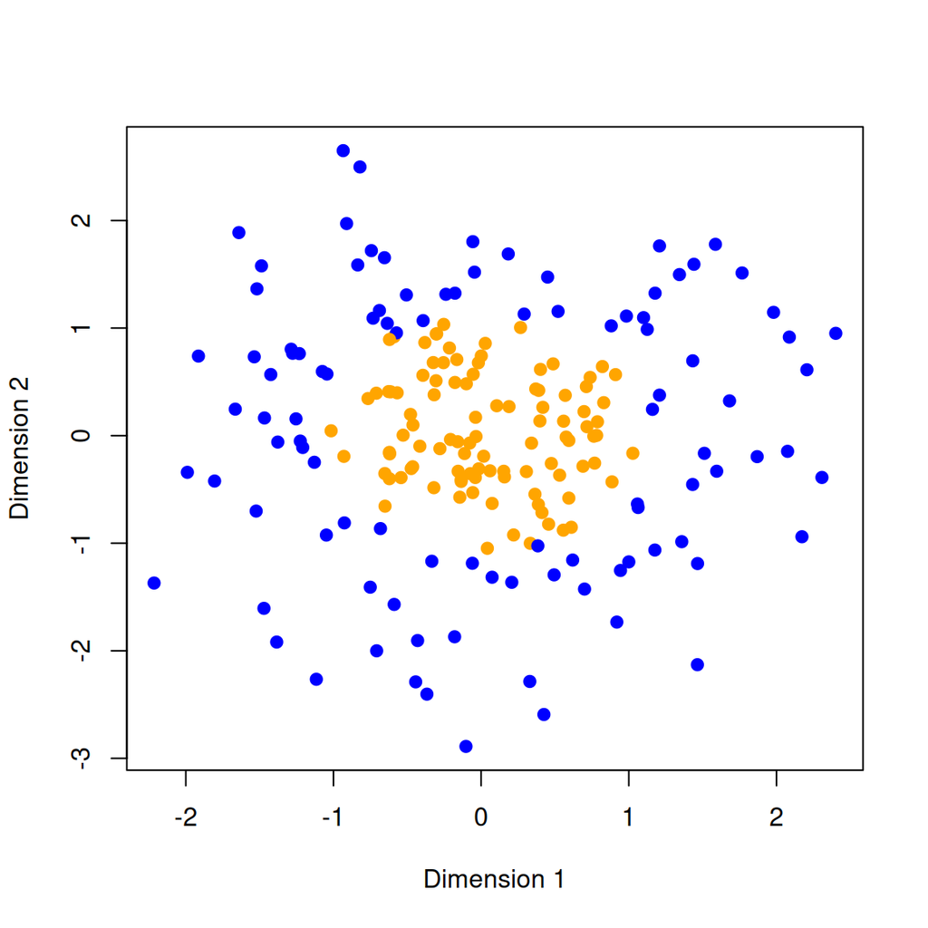

- `"density"`: removing data with the bigger nearest neigbhour distances:

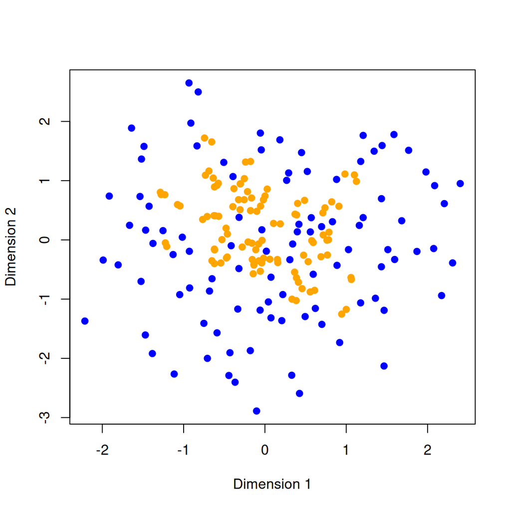

- `"evenness"`: pseudo-randomly removing data in proportions with higher density (“flattening the curve”)

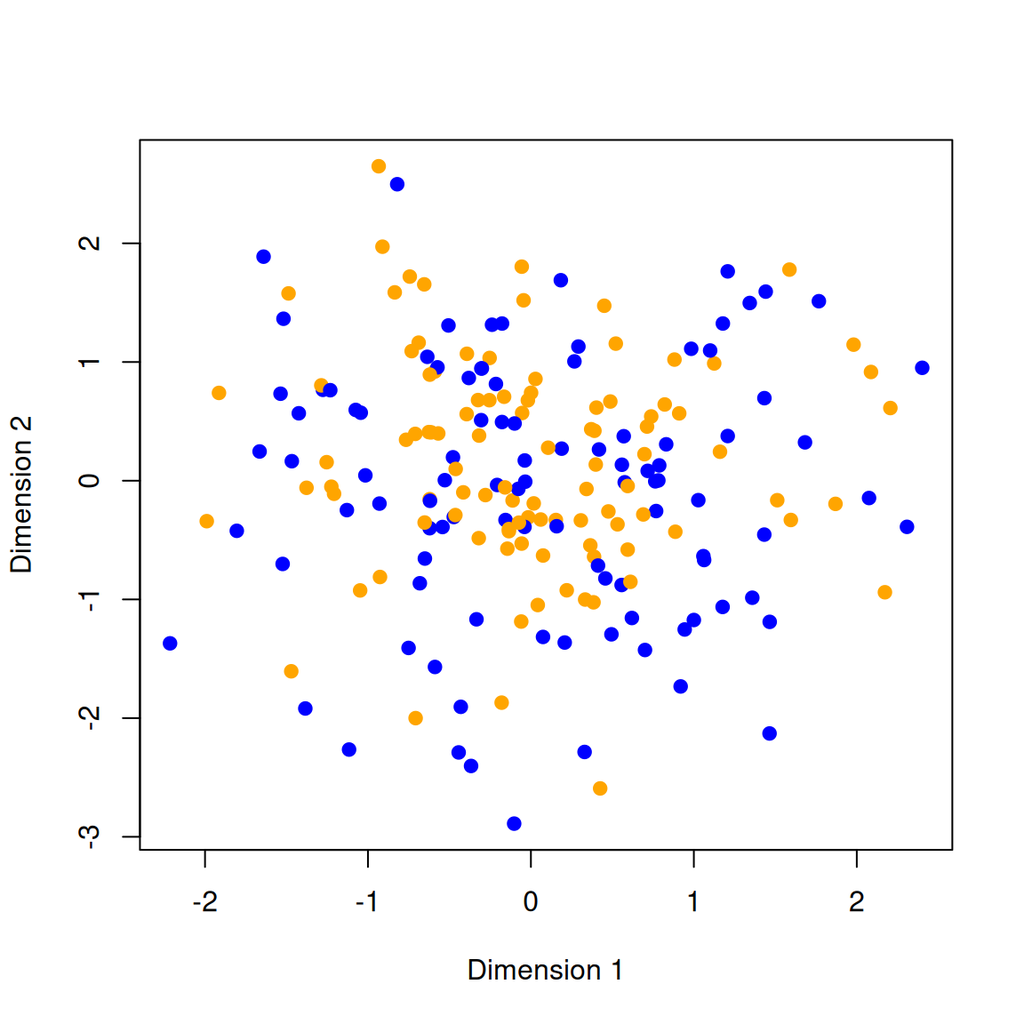

- `"position"`: removing data from a side of the trait space:

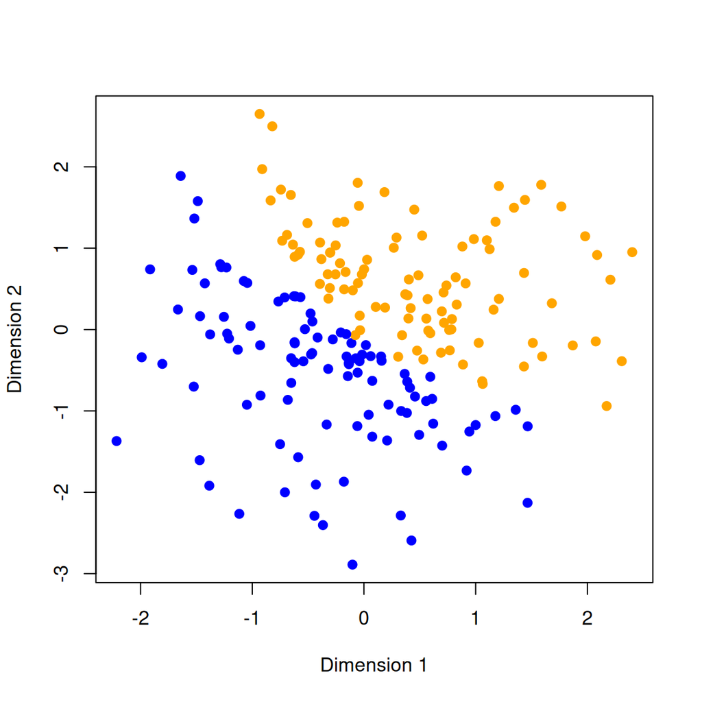

Choosing one of these reduction algorithm (ideally along side with the `"random"` one to understand the null results), we can then test how does the metric reacts to the requested changes. For example, let’s test the sum of ranges.

```r
set.seed(1)
## Testing the sum of ranges
test_sum_ranges <- test.metric(my_data,
                               metric = c(sum, ranges),
                               shifts = c("random", "size"))
```

By default, the replicates the space reduction (“shifts”) 3 times but you can increase it using the `replicates` option. You can summarise and plot the results using the generic S3 `plot` and `summary` funcctions:

```r
## How did the sum of ranges capture random changes and changes in size?
summary(test_sum_ranges)
```

```
##                    10%    20%    30%    40%    50%    60%    70%    80%    90%
## random          200.07 256.15 281.05 302.64 323.50 333.42 346.23 356.57 364.52
## size.increase   203.71 314.21 283.31 305.77 370.04 334.64 357.22 355.25 370.04
## size.hollowness 101.95 247.37 234.94 292.36 101.95 323.91 334.46 318.67 361.06
##                  100%    slope      p_value  R^2(adj)
## random          372.6 1.709334 1.051091e-15 0.8993423
## size.increase   372.6 1.380921 1.713306e-07 0.6160215
## size.hollowness 372.6 2.338168 2.556215e-05 0.4559003
```

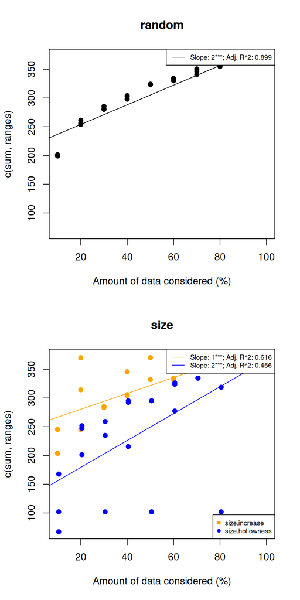

```r
plot(test_sum_ranges)
```

So here it seems that whether we randomly or specifically remove data from the trait space, the sum of ranges just increases in relation to the percentage of data considered (not the best behaviour!). We can then do the same for all the other metrics:

```r
set.seed(1)
## Testing the sum of ranges
test_prod_ranges <- test.metric(my_data,
                                metric = c(prod, ranges),
                                shifts = c("random", "size"),
                                save.steps = TRUE)
```

> Note here we used the `save.steps` function that saves the different removal stages for making fancy plots:

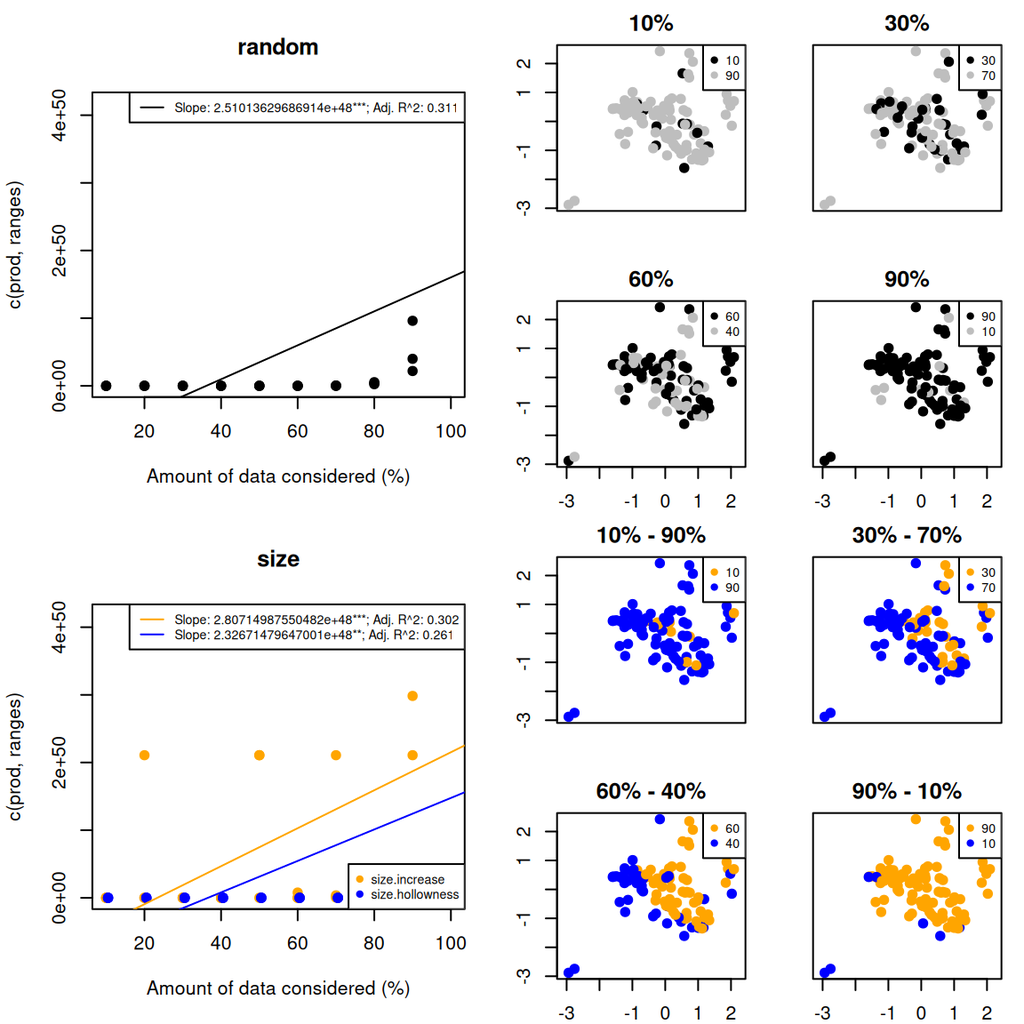

```r
plot(test_prod_ranges)
```

Note that here the results seem very bad! We get a lot of zeros basically. This is because of the curse of multidimensionality (= the more dimensions, the more the emptiness - find out more about that in [this course](https://github.com/TGuillerme/Morphological_traits), [chapter 3.2](https://githubraw.com/TGuillerme/Morphological_traits/main/gitbook/_book/from-trait%20spaces-to-disparity.html#the-curse-of-dimensionality)).

And finally a third example of a metric that seems to work alright:

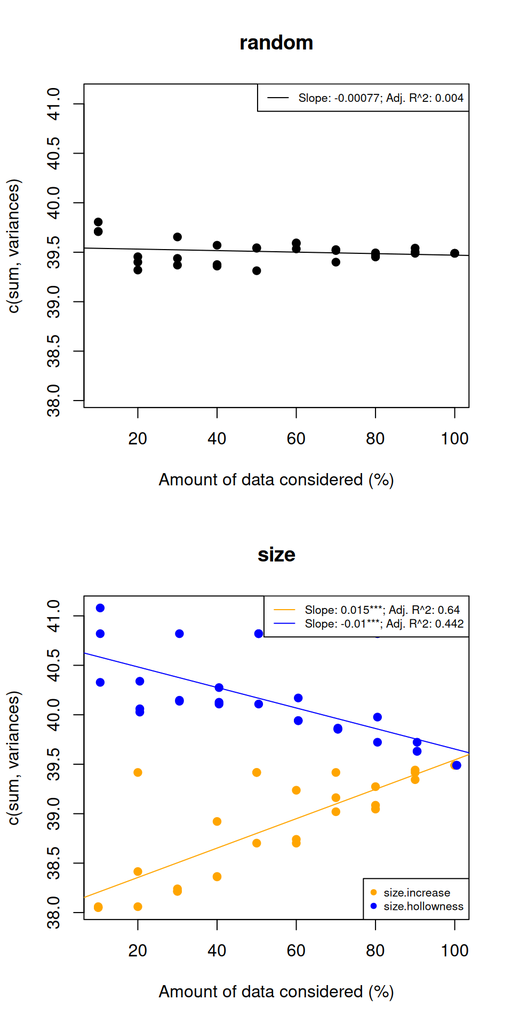

```r
set.seed(1)
## Testing the sum of ranges
test_sum_variances <- test.metric(my_data,
                                  metric = c(sum, variances),
                                  shifts = c("random", "size"))

## How did the sum of variances capture random changes and changes in size?
plot(test_sum_variances)
```

> In `moms` you can select the different metrics by selecting them in the top right corner. They are loosely sorted by categories. Alternatively, you can enter your own metric by choosing “User” in the “Metric type” menu (top right corner). This allows to either mix and match metrics from the list or by writing it yourself (tick “Show metric code” and then “Edit metric”). Note that if you’ve been using `moms` but you want to make your work reproducible, you click on the “Export code” button on the lower right corner to save all your work as a repeatable `R` script.

## *Finally* making the list

And that’s it! We can use this algorithm to test all of our metrics and then choose the one that seems the most appropriate to our question (what mechanism are we interested in?) and to our dataset (how is our data distributed, etc.).

# Bonus - design your own metrics

Here I’ve been demonstrating how to test metrics using a very restricted category of disparity metrics, they are all implemented in the `dispRity` package (which is a very small subset of the types of metrics that can exist!) and they are all “dimension level 1” metric. That means that when you calculate the metric you get one statistic summarising the trait space (e.g. one trait space = one value). This is fine for a lot of cases but nothing stops you from using “dimension level 2” metrics. These metrics describe the trait space using a distribution of statistics rather than a single one. For example, why not use the distributions of distances to the centroid rather than just the *median* distance to the centroid? Once you know how to compare point estimates, it’s not that complicated to compare distributions… More info about using disparity as distributions [here](https://raw.githack.com/TGuillerme/dispRity/master/inst/gitbook/_book/details-of-specific-functions.html#disparity-distribution).

But even better than using disparity a distribution is designing your own disparity metric! For example, a colleague here at Sheffield (Rob MacDonald - doing his PhD on bird color evolution) wanted to understand the “clumpiness” of his data. In the example dataset chosen here, that’d be about measuring whether they are some kind of isolated “islands” of elements compared to the rest of the distribution. We had a think and he quickly came up with a really nice solution: counting the number of neighbours for each element using this following function:

```r
## Counting neighbours
counting.neighbours <- function(matrix, radius) {
    ## Calculating the distance matrix
    distances <- as.matrix(dist(matrix))
    ## Counting the neigbhours per elements
    counts <- apply(distances, 1, function(one_row, radius) sum(one_row <= radius), radius = radius) - 1
    ## That's it
    return(counts)
}
```

Which we can explore using the `dispRity` function:

```r
## Count the neigbhours in our dataset
count_neighbours <- dispRity(my_data, metric = counting.neighbours, radius = 8.8)
summary(count_neighbours)
```

```
##   subsets  n obs.median  2.5%   25% 75% 97.5%
## 1   crown 52        7.0 0.275  4.75   9 18.45
## 2    stem 54       26.5 5.325 19.75  32 39.00
```

And test using the `test.metric` function (expecting it captures changes in density):

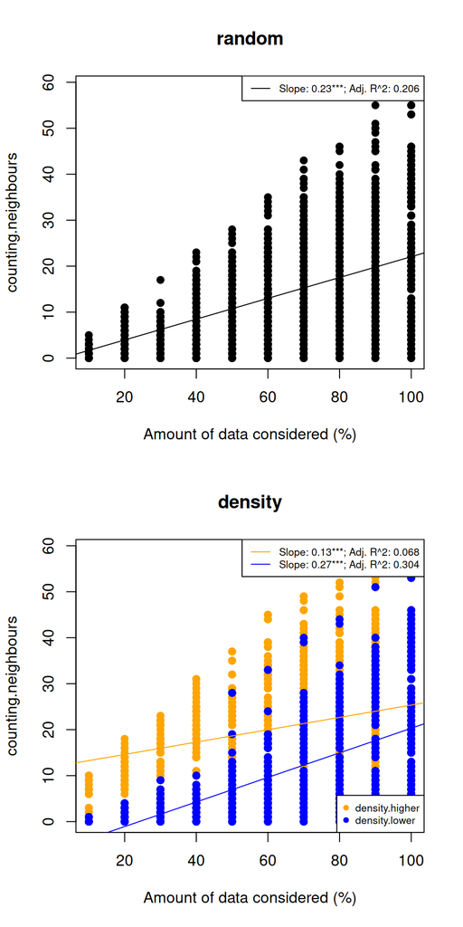

```r
## Testing the metric
testing_counts <- test.metric(my_data,
                              metric = counting.neighbours, radius = 8.8,
                              shifts = c("random", "density"))
plot(testing_counts)
```

This metric does seem capture a change in density in the dataset at hand. But maybe it’s also slightly sensitive to the number of species? Easy fix, let’s make it relative

```r
## Counting neighbours
counting.neighbours2 <- function(matrix, radius) {
    ## Calculating the distance matrix
    distances <- as.matrix(dist(matrix))
    ## Counting the neigbhours per elements
    counts <- apply(distances, 1, function(one_row, radius) sum(one_row <= radius), radius = radius) - 1
    ## That's it
    return(counts/nrow(distances))
}
```

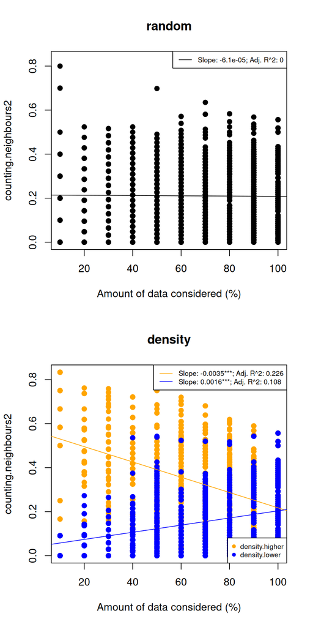

```r
## Testing the metric
testing_counts2 <- test.metric(my_data,
                               metric = counting.neighbours2, radius = 8.8,
                               shifts = c("random", "density"))
plot(testing_counts2)
```

# References

Beck R.M.D., Lee M.S.Y. 2014. [Ancient dates or accelerated rates? Morphological clocks and the antiquity of placental mammals](https://doi.org/10.1098/rspb.2014.1278). Proceedings of the Royal Society B: Biological Sciences. 281:20141278.

Guillerme T. 2018. [dispRity: A modular R package for measuring disparity](https://doi.org/10.1111/2041-210X.13022). Methods in Ecology and Evolution. 9:1755–1763.

Guillerme T., Cardoso P., Jørgensen M.W., Mammola S., Matthews T.J. 2024. The what, how and why of trait-based analyses in ecology. bioRxiv.:2024–06.

Guillerme T., Puttick M.N., Marcy A.E., Weisbecker V. 2020. Shifting spaces: Which disparity or dissimilarity measurement best summarize occupancy in multidimensional spaces? Ecology and evolution. 10:7261–7275.

Healy K., Ezard T.H.G., Jones O.R., Salguero-G’omez R., Buckley Y.M. 2019. [Animal life history is shaped by the pace of life and the distribution of age-specific mortality and reproduction](https://doi.org/10.1038/s41559-019-0938-7). Nature Ecology & Evolution. 2397-334X.

Hopkins M., Pearson K. 2016. Non-linear ontogenetic shape change in cryptolithus tesselatus (trilobita) using three-dimensional geometric morphometrics. Palaeontologia Electronica. 19:1–54.

Jones N.T., Germain R.M., Grainger T.N., Hall A.M., Baldwin L., Gilbert B. 2015. [Dispersal mode mediates the effect of patch size and patch connectivity on metacommunity diversity](https://doi.org/10.1111/1365-2745.12405). Journal of Ecology. 103:935–944.

Marcy A.E., Hadly E.A., Sherratt E., Garland K., Weisbecker V. 2016. Getting a head in hard soils: Convergent skull evolution and divergent allometric patterns explain shape variation in a highly diverse genus of pocket gophers (thomomys). BMC evolutionary biology. 16:207.

Wright D.F. 2017. [Phenotypic innovation and adaptive constraints in the evolutionary radiation of palaeozoic crinoids](https://doi.org/10.1038/s41598-017-13979-9). Scientific Reports. 7:13745.